# Risk Factor Analysis

## Outcome Variable

**Outcome Variable:** co_occurence

## Predictor Variables

**Intervention Variable:** ever_underweight06

**Adjustment Set:**

unadjusted

## Stratifying Variables

The analysis was stratified on these variable(s):

- studyid
- country

## Data Summary

| studyid | country | ever_underweight06 | co_occurence | n_cell | n |
| --- | --- | --- | --- | --- | --- |
| ki0047075b-MAL-ED | BANGLADESH | 0 | 0 | 153 | 221 |
| ki0047075b-MAL-ED | BANGLADESH | 0 | 1 | 3 | 221 |
| ki0047075b-MAL-ED | BANGLADESH | 1 | 0 | 54 | 221 |
| ki0047075b-MAL-ED | BANGLADESH | 1 | 1 | 11 | 221 |
| ki0047075b-MAL-ED | BRAZIL | 0 | 0 | 172 | 180 |
| ki0047075b-MAL-ED | BRAZIL | 0 | 1 | 0 | 180 |
| ki0047075b-MAL-ED | BRAZIL | 1 | 0 | 7 | 180 |
| ki0047075b-MAL-ED | BRAZIL | 1 | 1 | 1 | 180 |
| ki0047075b-MAL-ED | INDIA | 0 | 0 | 140 | 228 |
| ki0047075b-MAL-ED | INDIA | 0 | 1 | 0 | 228 |
| ki0047075b-MAL-ED | INDIA | 1 | 0 | 71 | 228 |
| ki0047075b-MAL-ED | INDIA | 1 | 1 | 17 | 228 |
| ki0047075b-MAL-ED | NEPAL | 0 | 0 | 193 | 229 |
| ki0047075b-MAL-ED | NEPAL | 0 | 1 | 0 | 229 |
| ki0047075b-MAL-ED | NEPAL | 1 | 0 | 32 | 229 |
| ki0047075b-MAL-ED | NEPAL | 1 | 1 | 4 | 229 |
| ki0047075b-MAL-ED | PERU | 0 | 0 | 186 | 222 |
| ki0047075b-MAL-ED | PERU | 0 | 1 | 1 | 222 |
| ki0047075b-MAL-ED | PERU | 1 | 0 | 30 | 222 |
| ki0047075b-MAL-ED | PERU | 1 | 1 | 5 | 222 |
| ki0047075b-MAL-ED | SOUTH AFRICA | 0 | 0 | 204 | 241 |
| ki0047075b-MAL-ED | SOUTH AFRICA | 0 | 1 | 2 | 241 |
| ki0047075b-MAL-ED | SOUTH AFRICA | 1 | 0 | 33 | 241 |
| ki0047075b-MAL-ED | SOUTH AFRICA | 1 | 1 | 2 | 241 |
| ki0047075b-MAL-ED | TANZANIA, UNITED REPUBLIC OF | 0 | 0 | 191 | 225 |
| ki0047075b-MAL-ED | TANZANIA, UNITED REPUBLIC OF | 0 | 1 | 0 | 225 |
| ki0047075b-MAL-ED | TANZANIA, UNITED REPUBLIC OF | 1 | 0 | 33 | 225 |
| ki0047075b-MAL-ED | TANZANIA, UNITED REPUBLIC OF | 1 | 1 | 1 | 225 |
| ki1000108-CMC-V-BCS-2002 | INDIA | 0 | 0 | 191 | 364 |
| ki1000108-CMC-V-BCS-2002 | INDIA | 0 | 1 | 1 | 364 |

[output cut: 90 more lines]

The following strata were considered:

- studyid: ki0047075b-MAL-ED, country: BANGLADESH
- studyid: ki0047075b-MAL-ED, country: BRAZIL
- studyid: ki0047075b-MAL-ED, country: INDIA
- studyid: ki0047075b-MAL-ED, country: NEPAL
- studyid: ki0047075b-MAL-ED, country: PERU
- studyid: ki0047075b-MAL-ED, country: SOUTH AFRICA
- studyid: ki0047075b-MAL-ED, country: TANZANIA, UNITED REPUBLIC OF
- studyid: ki1000108-CMC-V-BCS-2002, country: INDIA
- studyid: ki1000108-IRC, country: INDIA
- studyid: ki1000109-EE, country: PAKISTAN
- studyid: ki1000109-ResPak, country: PAKISTAN
- studyid: ki1000304b-SAS-CompFeed, country: INDIA
- studyid: ki1000304b-SAS-FoodSuppl, country: INDIA
- studyid: ki1017093-NIH-Birth, country: BANGLADESH
- studyid: ki1017093b-PROVIDE, country: BANGLADESH
- studyid: ki1017093c-NIH-Crypto, country: BANGLADESH
- studyid: ki1066203-TanzaniaChild2, country: TANZANIA, UNITED REPUBLIC OF
- studyid: ki1101329-Keneba, country: GAMBIA
- studyid: ki1113344-GMS-Nepal, country: NEPAL
- studyid: ki1114097-CMIN, country: BANGLADESH
- studyid: ki1114097-CMIN, country: BRAZIL
- studyid: ki1114097-CMIN, country: GUINEA-BISSAU
- studyid: ki1114097-CMIN, country: PERU
- studyid: ki1114097-CONTENT, country: PERU
- studyid: ki1119695-PROBIT, country: BELARUS
- studyid: ki1126311-ZVITAMBO, country: ZIMBABWE
- studyid: ki1135781-COHORTS, country: GUATEMALA
- studyid: ki1135781-COHORTS, country: PHILIPPINES
- studyid: ki1148112-LCNI-5, country: MALAWI
- studyid: kiGH5241-JiVitA-4, country: BANGLADESH

### Dropped Strata

Some strata were dropped due to rare outcomes:

- studyid: ki0047075b-MAL-ED, country: BANGLADESH
- studyid: ki0047075b-MAL-ED, country: BRAZIL
- studyid: ki0047075b-MAL-ED, country: INDIA
- studyid: ki0047075b-MAL-ED, country: NEPAL
- studyid: ki0047075b-MAL-ED, country: PERU
- studyid: ki0047075b-MAL-ED, country: SOUTH AFRICA
- studyid: ki0047075b-MAL-ED, country: TANZANIA, UNITED REPUBLIC OF
- studyid: ki1000108-CMC-V-BCS-2002, country: INDIA
- studyid: ki1000108-IRC, country: INDIA
- studyid: ki1000109-ResPak, country: PAKISTAN
- studyid: ki1114097-CMIN, country: BANGLADESH
- studyid: ki1114097-CMIN, country: BRAZIL
- studyid: ki1114097-CMIN, country: PERU
- studyid: ki1114097-CONTENT, country: PERU
- studyid: ki1119695-PROBIT, country: BELARUS
- studyid: ki1148112-LCNI-5, country: MALAWI

## Methods Detail

We’re interested in the causal parameters $E[Y_a]$ for all values of $a \in \mathcal{A}$. These parameters represent the mean outcome if, possibly contrary to fact, we intervened to set all units to have $A=a$. Under the randomization and positivity assumptions, these are identified by the statistical parameters $\psi_a=E_W[E_{Y|A,W}(Y|A=a,W)]$. In addition, we’re interested in the mean of $Y$, $E[Y]$ under no intervention (the observed mean). We will estimate these parameters by using SuperLearner to fit the relevant likelihood factors – $E_{Y|A,W}(Y|A=a,W)$ and $p(A=a|W)$, and then updating our likelihood fit using a joint TMLE.

For unadjusted analyses ($W=\{\}$), initial likelihoods were estimated using Lrnr_glm to estimate the simple $E(Y|A)$ and Lrnr_mean to estimate $p(A)$. For adjusted analyses, a small library containing Lrnr_glmnet, Lrnr_xgboost, and Lrnr_mean was used.

Having estimated these parameters, we will then use the delta method to estimate relative risks and attributable risks relative to a prespecified baseline level of $A$.

# Results Detail

## Results Plots

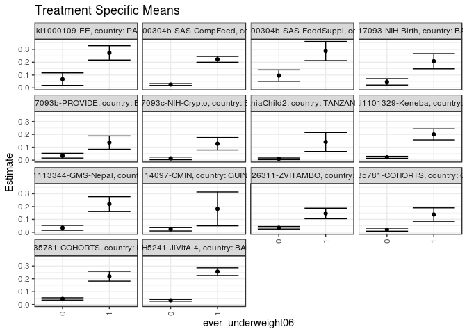

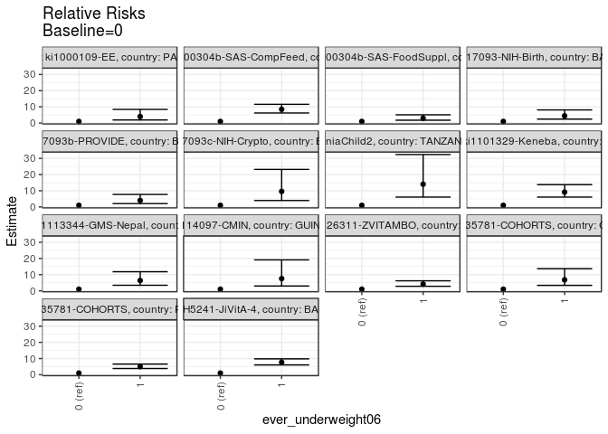

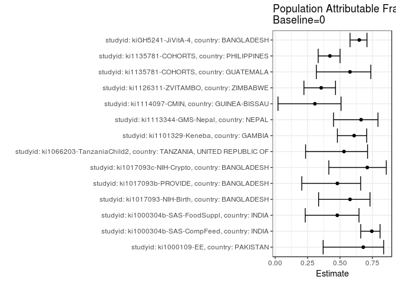

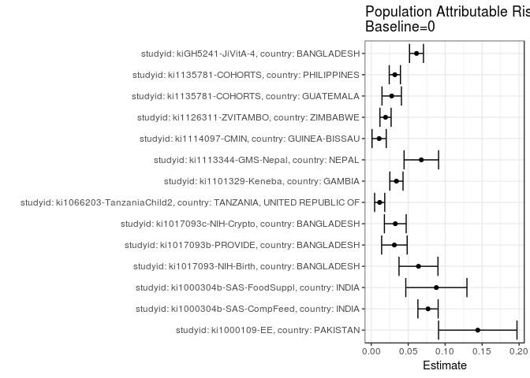

## Results Table

### Parameter: TSM

| studyid | country | intervention_level | baseline_level | estimate | ci_lower | ci_upper |
| --- | --- | --- | --- | --- | --- | --- |
| ki1000109-EE | PAKISTAN | 0 | NA | 0.0679612 | 0.0192868 | 0.1166355 |
| ki1000109-EE | PAKISTAN | 1 | NA | 0.2723577 | 0.2166478 | 0.3280676 |
| ki1000304b-SAS-CompFeed | INDIA | 0 | NA | 0.0262467 | 0.0190775 | 0.0334159 |
| ki1000304b-SAS-CompFeed | INDIA | 1 | NA | 0.2224490 | 0.1998446 | 0.2450533 |
| ki1000304b-SAS-FoodSuppl | INDIA | 0 | NA | 0.0958084 | 0.0510965 | 0.1405203 |
| ki1000304b-SAS-FoodSuppl | INDIA | 1 | NA | 0.2867133 | 0.2124733 | 0.3609532 |
| ki1017093-NIH-Birth | BANGLADESH | 0 | NA | 0.0467626 | 0.0219171 | 0.0716081 |
| ki1017093-NIH-Birth | BANGLADESH | 1 | NA | 0.2076503 | 0.1488176 | 0.2664830 |
| ki1017093b-PROVIDE | BANGLADESH | 0 | NA | 0.0339426 | 0.0157909 | 0.0520942 |
| ki1017093b-PROVIDE | BANGLADESH | 1 | NA | 0.1360947 | 0.0843516 | 0.1878377 |
| ki1017093c-NIH-Crypto | BANGLADESH | 0 | NA | 0.0132450 | 0.0027091 | 0.0237810 |
| ki1017093c-NIH-Crypto | BANGLADESH | 1 | NA | 0.1270718 | 0.0785133 | 0.1756303 |
| ki1066203-TanzaniaChild2 | TANZANIA, UNITED REPUBLIC OF | 0 | NA | 0.0100559 | 0.0035159 | 0.0165958 |
| ki1066203-TanzaniaChild2 | TANZANIA, UNITED REPUBLIC OF | 1 | NA | 0.1411765 | 0.0671148 | 0.2152381 |
| ki1101329-Keneba | GAMBIA | 0 | NA | 0.0218464 | 0.0142383 | 0.0294544 |
| ki1101329-Keneba | GAMBIA | 1 | NA | 0.2000000 | 0.1571541 | 0.2428459 |
| ki1113344-GMS-Nepal | NEPAL | 0 | NA | 0.0344828 | 0.0152945 | 0.0536710 |
| ki1113344-GMS-Nepal | NEPAL | 1 | NA | 0.2200000 | 0.1625370 | 0.2774630 |
| ki1114097-CMIN | GUINEA-BISSAU | 0 | NA | 0.0241228 | 0.0100260 | 0.0382196 |
| ki1114097-CMIN | GUINEA-BISSAU | 1 | NA | 0.1818182 | 0.0500898 | 0.3135465 |
| ki1126311-ZVITAMBO | ZIMBABWE | 0 | NA | 0.0350621 | 0.0253156 | 0.0448085 |
| ki1126311-ZVITAMBO | ZIMBABWE | 1 | NA | 0.1463415 | 0.1054376 | 0.1872453 |
| ki1135781-COHORTS | GUATEMALA | 0 | NA | 0.0202578 | 0.0084000 | 0.0321157 |
| ki1135781-COHORTS | GUATEMALA | 1 | NA | 0.1377246 | 0.0854218 | 0.1900273 |
| ki1135781-COHORTS | PHILIPPINES | 0 | NA | 0.0436488 | 0.0347789 | 0.0525188 |
| ki1135781-COHORTS | PHILIPPINES | 1 | NA | 0.2200000 | 0.1817186 | 0.2582814 |
| kiGH5241-JiVitA-4 | BANGLADESH | 0 | NA | 0.0331561 | 0.0261618 | 0.0401504 |
| kiGH5241-JiVitA-4 | BANGLADESH | 1 | NA | 0.2557756 | 0.2256663 | 0.2858849 |

### Parameter: E(Y)

| studyid | country | intervention_level | baseline_level | estimate | ci_lower | ci_upper |
| --- | --- | --- | --- | --- | --- | --- |
| ki1000109-EE | PAKISTAN | NA | NA | 0.2120344 | 0.1690891 | 0.2549796 |
| ki1000304b-SAS-CompFeed | INDIA | NA | NA | 0.1030351 | 0.0907482 | 0.1153221 |
| ki1000304b-SAS-FoodSuppl | INDIA | NA | NA | 0.1838710 | 0.1406788 | 0.2270631 |
| ki1017093-NIH-Birth | BANGLADESH | NA | NA | 0.1106291 | 0.0819645 | 0.1392936 |
| ki1017093b-PROVIDE | BANGLADESH | NA | NA | 0.0652174 | 0.0446012 | 0.0858336 |
| ki1017093c-NIH-Crypto | BANGLADESH | NA | NA | 0.0457413 | 0.0294659 | 0.0620168 |
| ki1066203-TanzaniaChild2 | TANZANIA, UNITED REPUBLIC OF | NA | NA | 0.0214286 | 0.0123577 | 0.0304995 |
| ki1101329-Keneba | GAMBIA | NA | NA | 0.0558723 | 0.0451208 | 0.0666238 |
| ki1113344-GMS-Nepal | NEPAL | NA | NA | 0.1021898 | 0.0768063 | 0.1275732 |
| ki1114097-CMIN | GUINEA-BISSAU | NA | NA | 0.0347648 | 0.0185122 | 0.0510175 |
| ki1126311-ZVITAMBO | ZIMBABWE | NA | NA | 0.0543478 | 0.0434257 | 0.0652699 |
| ki1135781-COHORTS | GUATEMALA | NA | NA | 0.0478873 | 0.0321700 | 0.0636047 |
| ki1135781-COHORTS | PHILIPPINES | NA | NA | 0.0755323 | 0.0651490 | 0.0859156 |
| kiGH5241-JiVitA-4 | BANGLADESH | NA | NA | 0.0943525 | 0.0838117 | 0.1048932 |

### Parameter: RR

| studyid | country | intervention_level | baseline_level | estimate | ci_lower | ci_upper |
| --- | --- | --- | --- | --- | --- | --- |
| ki1000109-EE | PAKISTAN | 0 | 0 | 1.000000 | 1.000000 | 1.000000 |
| ki1000109-EE | PAKISTAN | 1 | 0 | 4.007549 | 1.902817 | 8.440355 |
| ki1000304b-SAS-CompFeed | INDIA | 0 | 0 | 1.000000 | 1.000000 | 1.000000 |
| ki1000304b-SAS-CompFeed | INDIA | 1 | 0 | 8.475306 | 6.204712 | 11.576817 |
| ki1000304b-SAS-FoodSuppl | INDIA | 0 | 0 | 1.000000 | 1.000000 | 1.000000 |
| ki1000304b-SAS-FoodSuppl | INDIA | 1 | 0 | 2.992570 | 1.754932 | 5.103031 |
| ki1017093-NIH-Birth | BANGLADESH | 0 | 0 | 1.000000 | 1.000000 | 1.000000 |
| ki1017093-NIH-Birth | BANGLADESH | 1 | 0 | 4.440521 | 2.431816 | 8.108437 |
| ki1017093b-PROVIDE | BANGLADESH | 0 | 0 | 1.000000 | 1.000000 | 1.000000 |
| ki1017093b-PROVIDE | BANGLADESH | 1 | 0 | 4.009558 | 2.080334 | 7.727874 |
| ki1017093c-NIH-Crypto | BANGLADESH | 0 | 0 | 1.000000 | 1.000000 | 1.000000 |
| ki1017093c-NIH-Crypto | BANGLADESH | 1 | 0 | 9.593923 | 3.969500 | 23.187641 |
| ki1066203-TanzaniaChild2 | TANZANIA, UNITED REPUBLIC OF | 0 | 0 | 1.000000 | 1.000000 | 1.000000 |
| ki1066203-TanzaniaChild2 | TANZANIA, UNITED REPUBLIC OF | 1 | 0 | 14.039216 | 6.087787 | 32.376226 |
| ki1101329-Keneba | GAMBIA | 0 | 0 | 1.000000 | 1.000000 | 1.000000 |
| ki1101329-Keneba | GAMBIA | 1 | 0 | 9.154839 | 6.082483 | 13.779089 |
| ki1113344-GMS-Nepal | NEPAL | 0 | 0 | 1.000000 | 1.000000 | 1.000000 |
| ki1113344-GMS-Nepal | NEPAL | 1 | 0 | 6.380000 | 3.450282 | 11.797413 |
| ki1114097-CMIN | GUINEA-BISSAU | 0 | 0 | 1.000000 | 1.000000 | 1.000000 |
| ki1114097-CMIN | GUINEA-BISSAU | 1 | 0 | 7.537190 | 2.971420 | 19.118548 |
| ki1126311-ZVITAMBO | ZIMBABWE | 0 | 0 | 1.000000 | 1.000000 | 1.000000 |
| ki1126311-ZVITAMBO | ZIMBABWE | 1 | 0 | 4.173781 | 2.814032 | 6.190563 |
| ki1135781-COHORTS | GUATEMALA | 0 | 0 | 1.000000 | 1.000000 | 1.000000 |
| ki1135781-COHORTS | GUATEMALA | 1 | 0 | 6.798585 | 3.383690 | 13.659868 |
| ki1135781-COHORTS | PHILIPPINES | 0 | 0 | 1.000000 | 1.000000 | 1.000000 |
| ki1135781-COHORTS | PHILIPPINES | 1 | 0 | 5.040224 | 3.857112 | 6.586239 |
| kiGH5241-JiVitA-4 | BANGLADESH | 0 | 0 | 1.000000 | 1.000000 | 1.000000 |
| kiGH5241-JiVitA-4 | BANGLADESH | 1 | 0 | 7.714288 | 6.060356 | 9.819594 |

### Parameter: PAR

| studyid | country | intervention_level | baseline_level | estimate | ci_lower | ci_upper |
| --- | --- | --- | --- | --- | --- | --- |
| ki1000109-EE | PAKISTAN | 0 | NA | 0.1440732 | 0.0910162 | 0.1971303 |
| ki1000304b-SAS-CompFeed | INDIA | 0 | NA | 0.0767884 | 0.0630911 | 0.0904858 |
| ki1000304b-SAS-FoodSuppl | INDIA | 0 | NA | 0.0880626 | 0.0467009 | 0.1294243 |
| ki1017093-NIH-Birth | BANGLADESH | 0 | NA | 0.0638665 | 0.0375141 | 0.0902189 |
| ki1017093b-PROVIDE | BANGLADESH | 0 | NA | 0.0312748 | 0.0140326 | 0.0485171 |
| ki1017093c-NIH-Crypto | BANGLADESH | 0 | NA | 0.0324963 | 0.0177563 | 0.0472363 |
| ki1066203-TanzaniaChild2 | TANZANIA, UNITED REPUBLIC OF | 0 | NA | 0.0113727 | 0.0045222 | 0.0182232 |
| ki1101329-Keneba | GAMBIA | 0 | NA | 0.0340259 | 0.0250915 | 0.0429603 |
| ki1113344-GMS-Nepal | NEPAL | 0 | NA | 0.0677070 | 0.0443643 | 0.0910497 |
| ki1114097-CMIN | GUINEA-BISSAU | 0 | NA | 0.0106420 | 0.0010373 | 0.0202467 |
| ki1126311-ZVITAMBO | ZIMBABWE | 0 | NA | 0.0192857 | 0.0117210 | 0.0268505 |
| ki1135781-COHORTS | GUATEMALA | 0 | NA | 0.0276295 | 0.0144928 | 0.0407662 |
| ki1135781-COHORTS | PHILIPPINES | 0 | NA | 0.0318835 | 0.0242950 | 0.0394720 |
| kiGH5241-JiVitA-4 | BANGLADESH | 0 | NA | 0.0611964 | 0.0517820 | 0.0706107 |

### Parameter: PAF

| studyid | country | intervention_level | baseline_level | estimate | ci_lower | ci_upper |
| --- | --- | --- | --- | --- | --- | --- |
| ki1000109-EE | PAKISTAN | 0 | NA | 0.6794805 | 0.3698803 | 0.8369631 |
| ki1000304b-SAS-CompFeed | INDIA | 0 | NA | 0.7452644 | 0.6599904 | 0.8091518 |
| ki1000304b-SAS-FoodSuppl | INDIA | 0 | NA | 0.4789368 | 0.2317805 | 0.6465765 |
| ki1017093-NIH-Birth | BANGLADESH | 0 | NA | 0.5773029 | 0.3348638 | 0.7313740 |
| ki1017093b-PROVIDE | BANGLADESH | 0 | NA | 0.4795474 | 0.2050979 | 0.6592399 |
| ki1017093c-NIH-Crypto | BANGLADESH | 0 | NA | 0.7104362 | 0.4137558 | 0.8569756 |
| ki1066203-TanzaniaChild2 | TANZANIA, UNITED REPUBLIC OF | 0 | NA | 0.5307263 | 0.2343771 | 0.7123677 |
| ki1101329-Keneba | GAMBIA | 0 | NA | 0.6089945 | 0.4797310 | 0.7061419 |
| ki1113344-GMS-Nepal | NEPAL | 0 | NA | 0.6625616 | 0.4500140 | 0.7929680 |
| ki1114097-CMIN | GUINEA-BISSAU | 0 | NA | 0.3061146 | 0.0215290 | 0.5079292 |
| ki1126311-ZVITAMBO | ZIMBABWE | 0 | NA | 0.3548576 | 0.2216440 | 0.4652720 |
| ki1135781-COHORTS | GUATEMALA | 0 | NA | 0.5769689 | 0.3175948 | 0.7377580 |
| ki1135781-COHORTS | PHILIPPINES | 0 | NA | 0.4221171 | 0.3317855 | 0.5002373 |
| kiGH5241-JiVitA-4 | BANGLADESH | 0 | NA | 0.6485933 | 0.5772578 | 0.7078914 |